# Horticulture Data- Table 7.2

## Data Analysis for State wise area and production

Satyam’s Tables: 7.2.2 to 7.2.5 & Shyam’s Tables- 7.2.5 to 7.2.6

#### Plot to show Biggest Area consumer State for each Horticulture Crop: 2014-18

Plot by Shyam

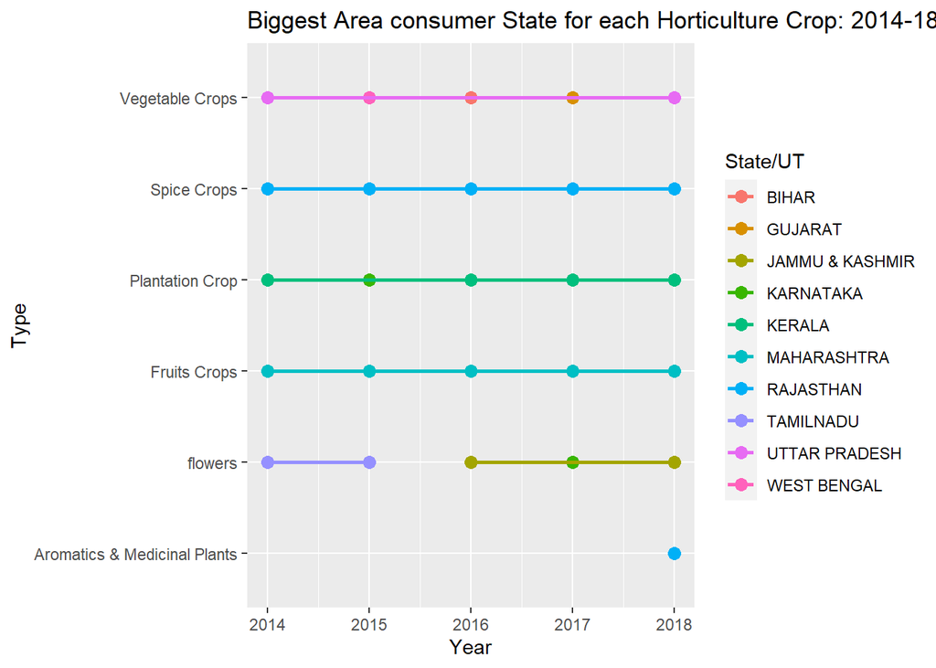

#### Highest Producer State for each Horticulture Crop: 2014-18

Plot by Shyam

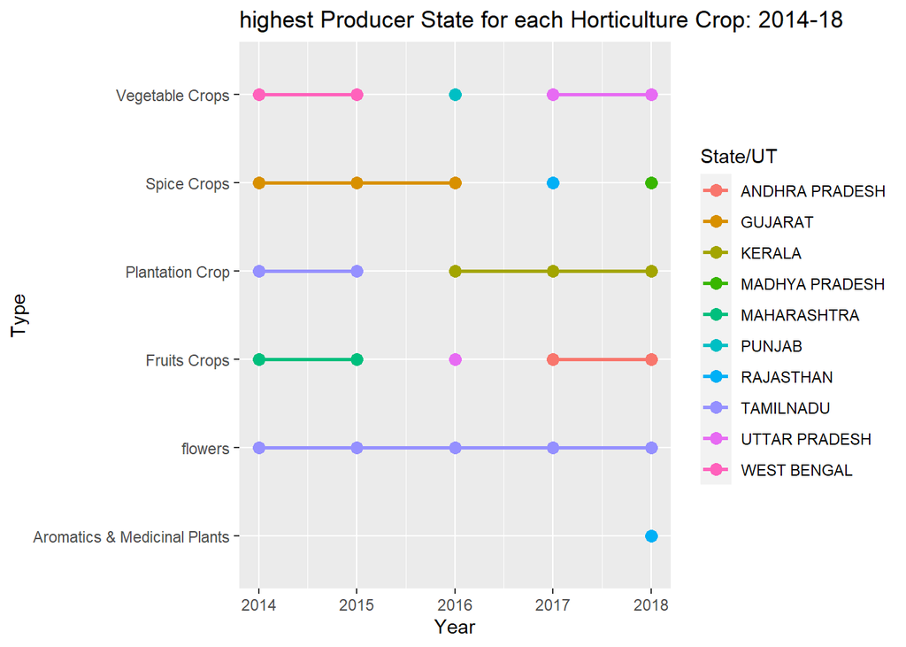

### Explanation

This data shows shows the leading producer state of each type of horticulture crop from 2014 to 2018. This graph is to be compared with biggest area occupier for each type of crop from 2014-18.

#### Plot to show production statistics of diffrent crops from 2014 - 18

Plot by Satyam

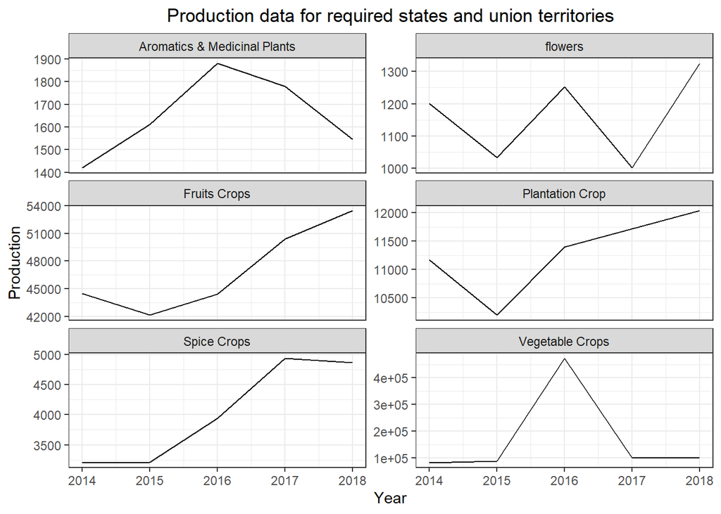

### Explanation

This data explains the production statistics for all different types of Horticulture crops from 2014-2018. Here we have used line because we had consistent data for all the years. It is preferable to use bar for these type of plots when the data is inconsistent.

#### Region vs production graph for all the crops

Plot by Shyam

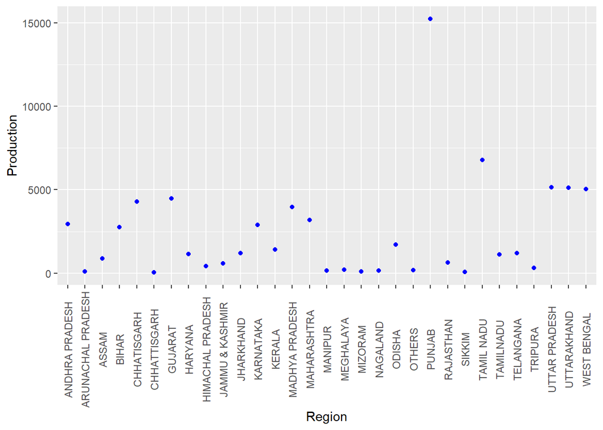